# ANCOVA in Vocabulario Não Ensinado (Vocabulario Não Ensinado)

Geiser C. Challco geiser@alumni.usp.br

- Descriptive Statistics of Initial Data
- ANCOVA and Pairwise for one factor: **grupo**
  - Without remove non-normal data
  - Computing ANCOVA and PairWise After removing non-normal data (OK)
    - Plots for ancova
    - Checking linearity assumption
    - Checking normality and homogeneity
- ANCOVA and Pairwise for two factors **grupo:Sexo**
  - Without remove non-normal data
  - Computing ANCOVA and PairWise After removing non-normal data (OK)
    - Plots for ancova
    - Checking linearity assumption
    - Checking normality and homogeneity
- ANCOVA and Pairwise for two factors **grupo:Zona**
  - Without remove non-normal data
  - Computing ANCOVA and PairWise After removing non-normal data (OK)
    - Plots for ancova
    - Checking linearity assumption
    - Checking normality and homogeneity
- ANCOVA and Pairwise for two factors **grupo:Cor.Raca**
  - Without remove non-normal data
  - Computing ANCOVA and PairWise After removing non-normal data (OK)
    - Plots for ancova
    - Checking linearity assumption
    - Checking normality and homogeneity
- ANCOVA and Pairwise for two factors **grupo:Serie**
  - Without remove non-normal data
  - Computing ANCOVA and PairWise After removing non-normal data (OK)
    - Plots for ancova
    - Checking linearity assumption
    - Checking normality and homogeneity
- Summary of Results
  - Descriptive Statistics
  - ANCOVA Table Comparison
  - PairWise Table Comparison
  - EMMS Table Comparison

**NOTE**:

- Teste ANCOVA para determinar se houve diferenças significativas no Vocabulario Não Ensinado (medido usando pre- e pos-testes).
- ANCOVA test to determine whether there were significant differences in Vocabulario Não Ensinado (measured using pre- and post-tests).

# Descriptive Statistics of Initial Data

```r
df <- get.descriptives(dat, c(dv.pre, dv.pos), c("grupo"),
                       include.global = T, symmetry.test = T, normality.test = F)
df <- plyr::rbind.fill(
  df, do.call(plyr::rbind.fill, lapply(lfatores2, FUN = function(f) {
    if (nrow(dat) > 0 && sum(!is.na(unique(dat[[f]]))) > 1)
      get.descriptives(dat, c(dv.pre,dv.pos), c("grupo", f),
                       symmetry.test = T, normality.test = F)
    }))
)
(df <- df[,c(fatores1[fatores1 %in% colnames(df)],"variable",
             colnames(df)[!colnames(df) %in% c(fatores1,"variable")])])
```

```
##           grupo Sexo   Zona Cor.Raca Serie            variable   n   mean median min max    sd    se
## 1      Controle <NA>   <NA>     <NA>  <NA> vocab.non.teach.pre 105 16.638   17.0  14  19 1.716 0.167
## 2  Experimental <NA>   <NA>     <NA>  <NA> vocab.non.teach.pre 124 16.935   17.0  14  19 1.666 0.150
## 3          <NA> <NA>   <NA>     <NA>  <NA> vocab.non.teach.pre 229 16.799   17.0  14  19 1.692 0.112
## 4      Controle <NA>   <NA>     <NA>  <NA> vocab.non.teach.pos 105 17.924   18.0   0  32 6.226 0.608
## 5  Experimental <NA>   <NA>     <NA>  <NA> vocab.non.teach.pos 124 17.492   18.0   5  31 5.125 0.460
## 6          <NA> <NA>   <NA>     <NA>  <NA> vocab.non.teach.pos 229 17.690   18.0   0  32 5.648 0.373
## 7      Controle    F   <NA>     <NA>  <NA> vocab.non.teach.pre  48 16.625   16.0  14  19 1.671 0.241
## 8      Controle    M   <NA>     <NA>  <NA> vocab.non.teach.pre  57 16.649   17.0  14  19 1.768 0.234
## 9  Experimental    F   <NA>     <NA>  <NA> vocab.non.teach.pre  61 16.852   17.0  14  19 1.662 0.213
## 10 Experimental    M   <NA>     <NA>  <NA> vocab.non.teach.pre  63 17.016   17.0  14  19 1.680 0.212
## 11     Controle    F   <NA>     <NA>  <NA> vocab.non.teach.pos  48 18.125   17.5   0  32 6.094 0.880
## 12     Controle    M   <NA>     <NA>  <NA> vocab.non.teach.pos  57 17.754   19.0   5  31 6.384 0.846
## 13 Experimental    F   <NA>     <NA>  <NA> vocab.non.teach.pos  61 18.393   19.0   7  29 4.360 0.558
## 14 Experimental    M   <NA>     <NA>  <NA> vocab.non.teach.pos  63 16.619   17.0   5  31 5.669 0.714
```

[output cut: 98 more lines]

| grupo | Sexo | Zona | Cor.Raca | Serie | variable | n | mean | median | min | max | sd | se | ci | iqr | symmetry | skewness | kurtosis |
| --- | --- | --- | --- | --- | --- | --- | --- | --- | --- | --- | --- | --- | --- | --- | --- | --- | --- |
| Controle |  |  |  |  | vocab.non.teach.pre | 105 | 16.638 | 17.0 | 14 | 19 | 1.716 | 0.167 | 0.332 | 3.00 | YES | -0.125 | -1.268 |
| Experimental |  |  |  |  | vocab.non.teach.pre | 124 | 16.935 | 17.0 | 14 | 19 | 1.666 | 0.150 | 0.296 | 3.00 | YES | -0.254 | -1.259 |
|  |  |  |  |  | vocab.non.teach.pre | 229 | 16.799 | 17.0 | 14 | 19 | 1.692 | 0.112 | 0.220 | 3.00 | YES | -0.199 | -1.247 |
| Controle |  |  |  |  | vocab.non.teach.pos | 105 | 17.924 | 18.0 | 0 | 32 | 6.226 | 0.608 | 1.205 | 8.00 | YES | -0.205 | -0.155 |
| Experimental |  |  |  |  | vocab.non.teach.pos | 124 | 17.492 | 18.0 | 5 | 31 | 5.125 | 0.460 | 0.911 | 7.00 | YES | -0.154 | -0.240 |
|  |  |  |  |  | vocab.non.teach.pos | 229 | 17.690 | 18.0 | 0 | 32 | 5.648 | 0.373 | 0.735 | 8.00 | YES | -0.166 | -0.063 |
| Controle | F |  |  |  | vocab.non.teach.pre | 48 | 16.625 | 16.0 | 14 | 19 | 1.671 | 0.241 | 0.485 | 3.00 | YES | 0.001 | -1.262 |
| Controle | M |  |  |  | vocab.non.teach.pre | 57 | 16.649 | 17.0 | 14 | 19 | 1.768 | 0.234 | 0.469 | 3.00 | YES | -0.214 | -1.330 |
| Experimental | F |  |  |  | vocab.non.teach.pre | 61 | 16.852 | 17.0 | 14 | 19 | 1.662 | 0.213 | 0.426 | 3.00 | YES | -0.134 | -1.368 |
| Experimental | M |  |  |  | vocab.non.teach.pre | 63 | 17.016 | 17.0 | 14 | 19 | 1.680 | 0.212 | 0.423 | 2.50 | YES | -0.366 | -1.179 |
| Controle | F |  |  |  | vocab.non.teach.pos | 48 | 18.125 | 17.5 | 0 | 32 | 6.094 | 0.880 | 1.769 | 8.00 | YES | -0.429 | 0.580 |
| Controle | M |  |  |  | vocab.non.teach.pos | 57 | 17.754 | 19.0 | 5 | 31 | 6.384 | 0.846 | 1.694 | 9.00 | YES | -0.029 | -0.734 |
| Experimental | F |  |  |  | vocab.non.teach.pos | 61 | 18.393 | 19.0 | 7 | 29 | 4.360 | 0.558 | 1.117 | 5.00 | YES | -0.362 | -0.117 |
| Experimental | M |  |  |  | vocab.non.teach.pos | 63 | 16.619 | 17.0 | 5 | 31 | 5.669 | 0.714 | 1.428 | 8.50 | YES | 0.121 | -0.398 |
| Controle |  | Rural |  |  | vocab.non.teach.pre | 53 | 16.774 | 17.0 | 14 | 19 | 1.836 | 0.252 | 0.506 | 3.00 | YES | -0.239 | -1.378 |
| Controle |  | Urbana |  |  | vocab.non.teach.pre | 24 | 16.458 | 16.0 | 14 | 19 | 1.503 | 0.307 | 0.635 | 2.25 | YES | 0.187 | -1.053 |
| Controle |  |  |  |  | vocab.non.teach.pre | 28 | 16.536 | 16.5 | 14 | 19 | 1.688 | 0.319 | 0.655 | 3.00 | YES | -0.171 | -1.367 |
| Experimental |  | Rural |  |  | vocab.non.teach.pre | 54 | 17.019 | 17.0 | 14 | 19 | 1.584 | 0.216 | 0.432 | 2.75 | YES | -0.225 | -1.293 |
| Experimental |  | Urbana |  |  | vocab.non.teach.pre | 33 | 16.909 | 17.0 | 14 | 19 | 1.665 | 0.290 | 0.590 | 3.00 | YES | -0.294 | -1.264 |
| Experimental |  |  |  |  | vocab.non.teach.pre | 37 | 16.838 | 17.0 | 14 | 19 | 1.818 | 0.299 | 0.606 | 4.00 | YES | -0.198 | -1.456 |
| Controle |  | Rural |  |  | vocab.non.teach.pos | 53 | 18.113 | 19.0 | 4 | 30 | 6.583 | 0.904 | 1.814 | 10.00 | YES | -0.209 | -1.016 |
| Controle |  | Urbana |  |  | vocab.non.teach.pos | 24 | 18.583 | 18.0 | 5 | 32 | 4.969 | 1.014 | 2.098 | 3.25 | YES | 0.057 | 1.885 |
| Controle |  |  |  |  | vocab.non.teach.pos | 28 | 17.000 | 17.0 | 0 | 31 | 6.594 | 1.246 | 2.557 | 7.50 | YES | -0.166 | 0.192 |
| Experimental |  | Rural |  |  | vocab.non.teach.pos | 54 | 17.704 | 18.0 | 5 | 31 | 5.138 | 0.699 | 1.402 | 6.00 | YES | 0.071 | 0.173 |
| Experimental |  | Urbana |  |  | vocab.non.teach.pos | 33 | 18.182 | 18.0 | 7 | 27 | 4.633 | 0.807 | 1.643 | 5.00 | YES | -0.379 | -0.338 |
| Experimental |  |  |  |  | vocab.non.teach.pos | 37 | 16.568 | 17.0 | 5 | 25 | 5.515 | 0.907 | 1.839 | 9.00 | YES | -0.178 | -1.037 |
| Controle |  |  | Branca |  | vocab.non.teach.pre | 11 | 17.091 | 18.0 | 14 | 19 | 1.868 | 0.563 | 1.255 | 2.50 | NO | -0.537 | -1.305 |
| Controle |  |  | Indígena |  | vocab.non.teach.pre | 3 | 16.667 | 17.0 | 14 | 19 | 2.517 | 1.453 | 6.252 | 2.50 | few data | 0.000 | 0.000 |
| Controle |  |  | Parda |  | vocab.non.teach.pre | 36 | 16.583 | 16.5 | 14 | 19 | 1.842 | 0.307 | 0.623 | 3.00 | YES | -0.089 | -1.516 |
| Controle |  |  | Preta |  | vocab.non.teach.pre | 1 | 16.000 | 16.0 | 16 | 16 |  |  |  | 0.00 | few data | 0.000 | 0.000 |
| Controle |  |  |  |  | vocab.non.teach.pre | 54 | 16.593 | 16.5 | 14 | 19 | 1.608 | 0.219 | 0.439 | 2.75 | YES | -0.057 | -1.141 |
| Experimental |  |  | Branca |  | vocab.non.teach.pre | 12 | 17.417 | 18.0 | 14 | 19 | 1.881 | 0.543 | 1.195 | 2.50 | NO | -0.557 | -1.387 |
| Experimental |  |  | Indígena |  | vocab.non.teach.pre | 2 | 16.500 | 16.5 | 15 | 18 | 2.121 | 1.500 | 19.059 | 1.50 | few data | 0.000 | 0.000 |
| Experimental |  |  | Parda |  | vocab.non.teach.pre | 41 | 17.049 | 18.0 | 14 | 19 | 1.731 | 0.270 | 0.546 | 4.00 | YES | -0.355 | -1.401 |
| Experimental |  |  |  |  | vocab.non.teach.pre | 69 | 16.797 | 17.0 | 14 | 19 | 1.596 | 0.192 | 0.383 | 3.00 | YES | -0.164 | -1.150 |
| Controle |  |  | Branca |  | vocab.non.teach.pos | 11 | 18.273 | 20.0 | 9 | 25 | 6.182 | 1.864 | 4.153 | 11.00 | YES | -0.221 | -1.835 |
| Controle |  |  | Indígena |  | vocab.non.teach.pos | 3 | 18.000 | 18.0 | 12 | 24 | 6.000 | 3.464 | 14.905 | 6.00 | few data | 0.000 | 0.000 |
| Controle |  |  | Parda |  | vocab.non.teach.pos | 36 | 18.861 | 19.5 | 0 | 32 | 7.499 | 1.250 | 2.537 | 10.00 | NO | -0.509 | -0.293 |
| Controle |  |  | Preta |  | vocab.non.teach.pos | 1 | 18.000 | 18.0 | 18 | 18 |  |  |  | 0.00 | few data | 0.000 | 0.000 |
| Controle |  |  |  |  | vocab.non.teach.pos | 54 | 17.222 | 17.5 | 5 | 31 | 5.407 | 0.736 | 1.476 | 6.75 | YES | 0.048 | -0.075 |
| Experimental |  |  | Branca |  | vocab.non.teach.pos | 12 | 14.083 | 15.5 | 5 | 20 | 4.379 | 1.264 | 2.782 | 5.25 | NO | -0.534 | -0.827 |
| Experimental |  |  | Indígena |  | vocab.non.teach.pos | 2 | 16.500 | 16.5 | 15 | 18 | 2.121 | 1.500 | 19.059 | 1.50 | few data | 0.000 | 0.000 |
| Experimental |  |  | Parda |  | vocab.non.teach.pos | 41 | 18.610 | 19.0 | 7 | 29 | 4.868 | 0.760 | 1.536 | 6.00 | YES | -0.056 | -0.445 |
| Experimental |  |  |  |  | vocab.non.teach.pos | 69 | 17.449 | 18.0 | 5 | 31 | 5.251 | 0.632 | 1.261 | 7.00 | YES | -0.212 | -0.375 |
| Controle |  |  |  | 6 ano | vocab.non.teach.pre | 39 | 16.462 | 16.0 | 14 | 19 | 1.790 | 0.287 | 0.580 | 3.00 | YES | 0.007 | -1.396 |
| Controle |  |  |  | 7 ano | vocab.non.teach.pre | 39 | 16.513 | 16.0 | 14 | 19 | 1.571 | 0.252 | 0.509 | 2.50 | YES | 0.017 | -1.095 |
| Controle |  |  |  | 8 ano | vocab.non.teach.pre | 17 | 17.176 | 18.0 | 14 | 19 | 1.704 | 0.413 | 0.876 | 2.00 | NO | -0.614 | -1.056 |
| Controle |  |  |  | 9 ano | vocab.non.teach.pre | 10 | 16.900 | 17.5 | 14 | 19 | 2.025 | 0.640 | 1.448 | 3.50 | YES | -0.312 | -1.713 |
| Experimental |  |  |  | 6 ano | vocab.non.teach.pre | 33 | 16.970 | 17.0 | 14 | 19 | 1.828 | 0.318 | 0.648 | 3.00 | YES | -0.462 | -1.213 |
| Experimental |  |  |  | 7 ano | vocab.non.teach.pre | 45 | 16.733 | 17.0 | 14 | 19 | 1.587 | 0.237 | 0.477 | 3.00 | YES | -0.103 | -1.322 |
| Experimental |  |  |  | 8 ano | vocab.non.teach.pre | 30 | 16.933 | 17.0 | 14 | 19 | 1.680 | 0.307 | 0.627 | 3.75 | YES | -0.068 | -1.573 |
| Experimental |  |  |  | 9 ano | vocab.non.teach.pre | 16 | 17.438 | 17.5 | 15 | 19 | 1.548 | 0.387 | 0.825 | 2.25 | YES | -0.396 | -1.407 |
| Controle |  |  |  | 6 ano | vocab.non.teach.pos | 39 | 16.821 | 18.0 | 4 | 27 | 5.693 | 0.912 | 1.846 | 7.50 | YES | -0.220 | -0.687 |
| Controle |  |  |  | 7 ano | vocab.non.teach.pos | 39 | 17.667 | 17.0 | 5 | 27 | 5.362 | 0.859 | 1.738 | 7.00 | YES | -0.329 | -0.311 |
| Controle |  |  |  | 8 ano | vocab.non.teach.pos | 17 | 20.412 | 22.0 | 0 | 32 | 9.063 | 2.198 | 4.660 | 14.00 | NO | -0.644 | -0.709 |
| Controle |  |  |  | 9 ano | vocab.non.teach.pos | 10 | 19.000 | 18.5 | 13 | 29 | 5.011 | 1.585 | 3.585 | 6.75 | NO | 0.539 | -0.896 |
| Experimental |  |  |  | 6 ano | vocab.non.teach.pos | 33 | 17.212 | 18.0 | 5 | 27 | 5.436 | 0.946 | 1.927 | 6.00 | YES | -0.368 | -0.451 |
| Experimental |  |  |  | 7 ano | vocab.non.teach.pos | 45 | 17.400 | 18.0 | 5 | 27 | 5.043 | 0.752 | 1.515 | 7.00 | NO | -0.506 | -0.355 |
| Experimental |  |  |  | 8 ano | vocab.non.teach.pos | 30 | 17.633 | 17.0 | 10 | 29 | 4.522 | 0.826 | 1.688 | 6.00 | YES | 0.236 | -0.465 |
| Experimental |  |  |  | 9 ano | vocab.non.teach.pos | 16 | 18.062 | 18.5 | 11 | 31 | 6.137 | 1.534 | 3.270 | 9.25 | YES | 0.411 | -1.007 |

# ANCOVA and Pairwise for one factor: **grupo**

## Without remove non-normal data

```r
pdat = remove_group_data(dat[!is.na(dat[["grupo"]]),], "vocab.non.teach.pos", "grupo")

pdat.long <- rbind(pdat[,c("id","grupo")], pdat[,c("id","grupo")])
pdat.long[["time"]] <- c(rep("pre", nrow(pdat)), rep("pos", nrow(pdat)))
pdat.long[["time"]] <- factor(pdat.long[["time"]], c("pre","pos"))
pdat.long[["vocab.non.teach"]] <- c(pdat[["vocab.non.teach.pre"]], pdat[["vocab.non.teach.pos"]])

aov = anova_test(pdat, vocab.non.teach.pos ~ vocab.non.teach.pre + grupo)
laov[["grupo"]] <- get_anova_table(aov)
```

```r
pwc <- emmeans_test(pdat, vocab.non.teach.pos ~ grupo, covariate = vocab.non.teach.pre,
                    p.adjust.method = "bonferroni")
```

```r
pwc.long <- emmeans_test(dplyr::group_by_at(pdat.long, "grupo"),
                          vocab.non.teach ~ time,
                          p.adjust.method = "bonferroni")
lpwc[["grupo"]] <- plyr::rbind.fill(pwc, pwc.long)
```

```r
ds <- get.descriptives(pdat, "vocab.non.teach.pos", "grupo", covar = "vocab.non.teach.pre")
ds <- merge(ds[ds$variable != "vocab.non.teach.pre",],
            ds[ds$variable == "vocab.non.teach.pre", !colnames(ds) %in% c("variable")],
            by = "grupo", all.x = T, suffixes = c("", ".vocab.non.teach.pre"))
ds <- merge(get_emmeans(pwc), ds, by = "grupo", suffixes = c(".emms", ""))
ds <- ds[,c("grupo","n","mean.vocab.non.teach.pre","se.vocab.non.teach.pre","mean","se","emmean","se.emms")]

colnames(ds) <- c("grupo", "N", paste0(c("M","SE")," (pre)"),
                  paste0(c("M","SE"), " (unadj)"), paste0(c("M", "SE"), " (adj)"))

lemms[["grupo"]] <- ds
```

## Computing ANCOVA and PairWise After removing non-normal data (OK)

```r
wdat = pdat

res = residuals(lm(vocab.non.teach.pos ~ vocab.non.teach.pre + grupo, data = wdat))
non.normal = getNonNormal(res, wdat$id, plimit = 0.05)

wdat = wdat[!wdat$id %in% non.normal,]

wdat.long <- rbind(wdat[,c("id","grupo")], wdat[,c("id","grupo")])
wdat.long[["time"]] <- c(rep("pre", nrow(wdat)), rep("pos", nrow(wdat)))
wdat.long[["time"]] <- factor(wdat.long[["time"]], c("pre","pos"))
wdat.long[["vocab.non.teach"]] <- c(wdat[["vocab.non.teach.pre"]], wdat[["vocab.non.teach.pos"]])

ldat[["grupo"]] = wdat

(non.normal)
```

```r
aov = anova_test(wdat, vocab.non.teach.pos ~ vocab.non.teach.pre + grupo)
laov[["grupo"]] <- merge(get_anova_table(aov), laov[["grupo"]], by="Effect", suffixes = c("","'"))

(df = get_anova_table(aov))
```

```
## ANOVA Table (type II tests)
##
##                Effect DFn DFd      F        p p<.05   ges
## 1 vocab.non.teach.pre   1 226 12.106 0.000603     * 0.051
## 2               grupo   1 226  0.797 0.373000       0.004
```

| Effect | DFn | DFd | F | p | p<.05 | ges |
| --- | --- | --- | --- | --- | --- | --- |
| vocab.non.teach.pre | 1 | 226 | 12.106 | 0.001 | * | 0.051 |
| grupo | 1 | 226 | 0.797 | 0.373 |  | 0.004 |

| term | .y. | group1 | group2 | df | statistic | p | p.adj | p.adj.signif |
| --- | --- | --- | --- | --- | --- | --- | --- | --- |
| vocab.non.teach.pre*grupo | vocab.non.teach.pos | Controle | Experimental | 226 | 0.893 | 0.373 | 0.373 | ns |

```r
pwc.long <- emmeans_test(dplyr::group_by_at(wdat.long, "grupo"),
                         vocab.non.teach ~ time,
                         p.adjust.method = "bonferroni")
lpwc[["grupo"]] <- merge(plyr::rbind.fill(pwc, pwc.long), lpwc[["grupo"]], by=c("grupo","term",".y.","group1","group2"), suffixes = c("","'"))
```

| grupo | term | .y. | group1 | group2 | df | statistic | p | p.adj | p.adj.signif |
| --- | --- | --- | --- | --- | --- | --- | --- | --- | --- |
| Controle | time | vocab.non.teach | pre | pos | 454 | -2.232 | 0.026 | 0.026 | * |
| Experimental | time | vocab.non.teach | pre | pos | 454 | -1.050 | 0.294 | 0.294 | ns |

```r
ds <- get.descriptives(wdat, "vocab.non.teach.pos", "grupo", covar = "vocab.non.teach.pre")
ds <- merge(ds[ds$variable != "vocab.non.teach.pre",],
            ds[ds$variable == "vocab.non.teach.pre", !colnames(ds) %in% c("variable")],
            by = "grupo", all.x = T, suffixes = c("", ".vocab.non.teach.pre"))
ds <- merge(get_emmeans(pwc), ds, by = "grupo", suffixes = c(".emms", ""))
ds <- ds[,c("grupo","n","mean.vocab.non.teach.pre","se.vocab.non.teach.pre","mean","se","emmean","se.emms")]

colnames(ds) <- c("grupo", "N", paste0(c("M","SE")," (pre)"),
                  paste0(c("M","SE"), " (unadj)"), paste0(c("M", "SE"), " (adj)"))

lemms[["grupo"]] <- merge(ds, lemms[["grupo"]], by=c("grupo"), suffixes = c("","'"))
```

| grupo | N | M (pre) | SE (pre) | M (unadj) | SE (unadj) | M (adj) | SE (adj) |
| --- | --- | --- | --- | --- | --- | --- | --- |
| Controle | 105 | 16.638 | 0.167 | 17.924 | 0.608 | 18.045 | 0.540 |
| Experimental | 124 | 16.935 | 0.150 | 17.492 | 0.460 | 17.389 | 0.497 |

### Plots for ancova

```r
plots <- oneWayAncovaPlots(
  wdat, "vocab.non.teach.pos", "grupo", aov, list("grupo"=pwc), addParam = c("mean_se"),
  font.label.size=10, step.increase=0.05, p.label="p.adj",
  subtitle = which(aov$Effect == "grupo"))
```

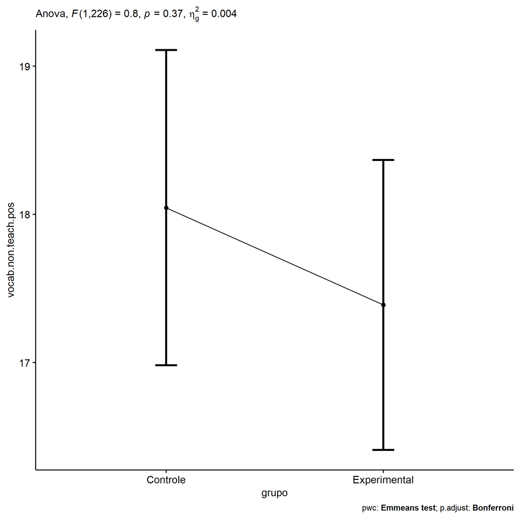

```r
if (!is.null(nrow(plots[["grupo"]]$data)))
  plots[["grupo"]] + ggplot2::scale_color_manual(values = color[["grupo"]])
```

```r
plots <- oneWayAncovaBoxPlots(
  wdat, "vocab.non.teach.pos", "grupo", aov, pwc, covar = "vocab.non.teach.pre",
  theme = "classic", color = color[["grupo"]],
  subtitle = which(aov$Effect == "grupo"))
```

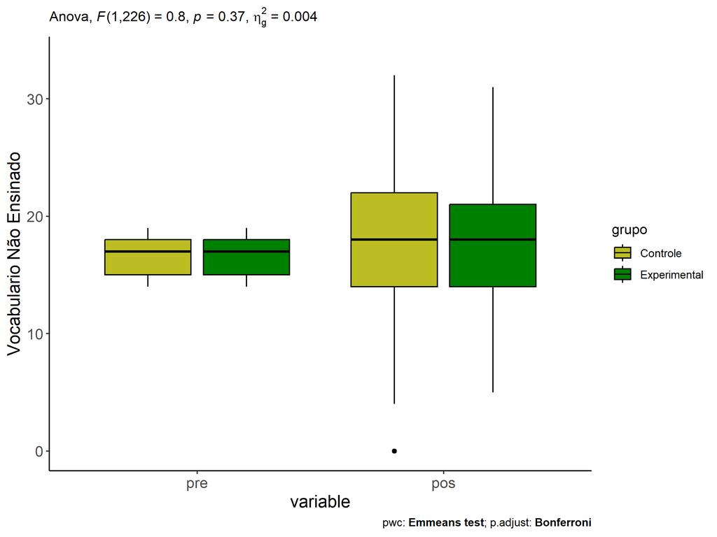

```r
if (length(unique(wdat[["grupo"]])) > 1)
  plots[["grupo"]] + ggplot2::ylab("Vocabulario Não Ensinado") + ggplot2::scale_x_discrete(labels=c('pre', 'pos'))
```

```r
if (length(unique(wdat.long[["grupo"]])) > 1)
  plots <- oneWayAncovaBoxPlots(
    wdat.long, "vocab.non.teach", "grupo", aov, pwc.long, pre.post = "time",
    theme = "classic", color = color$prepost)
```

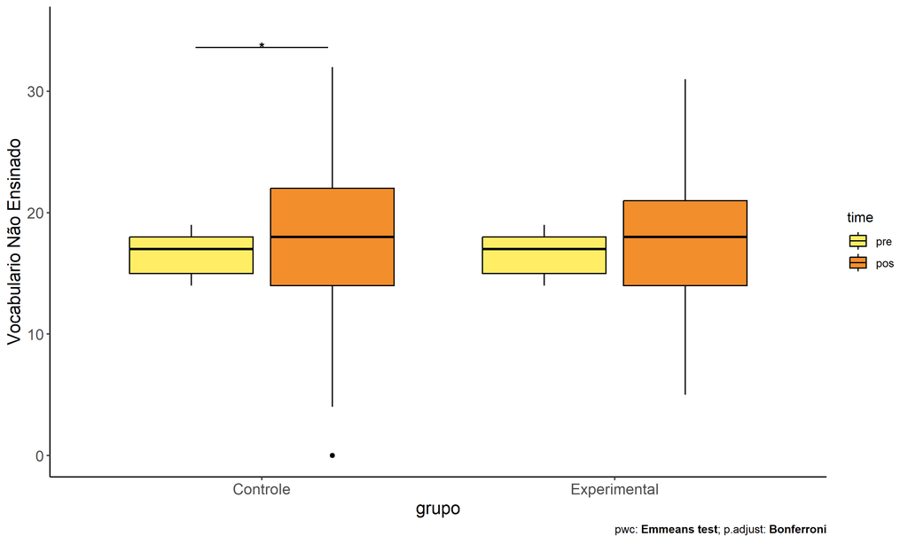

```r
if (length(unique(wdat.long[["grupo"]])) > 1)
  plots[["grupo"]] + ggplot2::ylab("Vocabulario Não Ensinado")
```

### Checking linearity assumption

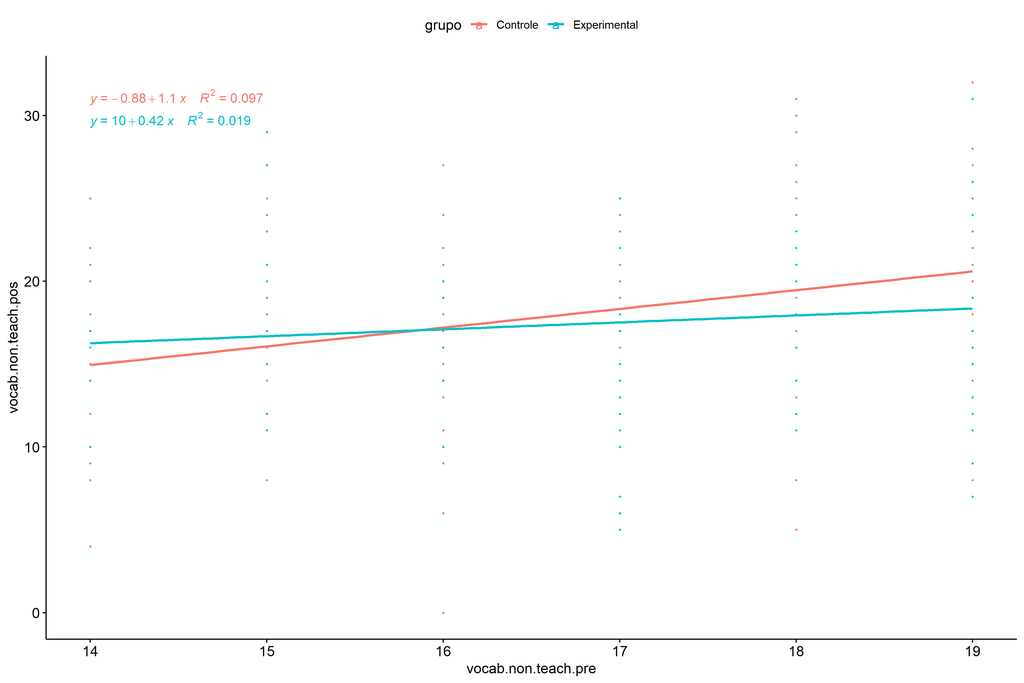

```r
ggscatter(wdat, x = "vocab.non.teach.pre", y = "vocab.non.teach.pos", size = 0.5,
          color = "grupo", add = "reg.line")+
  stat_regline_equation(
    aes(label =  paste(..eq.label.., ..rr.label.., sep = "~~~~"), color = grupo)
  )
```

### Checking normality and homogeneity

```r
res <- augment(lm(vocab.non.teach.pos ~ vocab.non.teach.pre + grupo, data = wdat))
```

```r
shapiro_test(res$.resid)
```

```
## # A tibble: 1 × 3
##   variable   statistic p.value
##   <chr>          <dbl>   <dbl>
## 1 res$.resid     0.991   0.143
```

```r
levene_test(res, .resid ~ grupo)
```

```
## # A tibble: 1 × 4
##     df1   df2 statistic     p
##   <int> <int>     <dbl> <dbl>
## 1     1   227      1.63 0.203
```

# ANCOVA and Pairwise for two factors **grupo:Sexo**

## Without remove non-normal data

```r
pdat = remove_group_data(dat[!is.na(dat[["grupo"]]) & !is.na(dat[["Sexo"]]),], "vocab.non.teach.pos", c("grupo","Sexo"))

pdat.long <- rbind(pdat[,c("id","grupo","Sexo")], pdat[,c("id","grupo","Sexo")])
pdat.long[["time"]] <- c(rep("pre", nrow(pdat)), rep("pos", nrow(pdat)))
pdat.long[["time"]] <- factor(pdat.long[["time"]], c("pre","pos"))
pdat.long[["vocab.non.teach"]] <- c(pdat[["vocab.non.teach.pre"]], pdat[["vocab.non.teach.pos"]])

aov = anova_test(pdat, vocab.non.teach.pos ~ vocab.non.teach.pre + grupo*Sexo)
laov[["grupo:Sexo"]] <- get_anova_table(aov)
```

```r
pwcs <- list()
pwcs[["Sexo"]] <- emmeans_test(
  group_by(pdat, grupo), vocab.non.teach.pos ~ Sexo,
  covariate = vocab.non.teach.pre, p.adjust.method = "bonferroni")
pwcs[["grupo"]] <- emmeans_test(
  group_by(pdat, Sexo), vocab.non.teach.pos ~ grupo,
  covariate = vocab.non.teach.pre, p.adjust.method = "bonferroni")

pwc <- plyr::rbind.fill(pwcs[["grupo"]], pwcs[["Sexo"]])
pwc <- pwc[,c("grupo","Sexo", colnames(pwc)[!colnames(pwc) %in% c("grupo","Sexo")])]
```

```r
pwc.long <- emmeans_test(dplyr::group_by_at(pdat.long, c("grupo","Sexo")),
                         vocab.non.teach ~ time,
                         p.adjust.method = "bonferroni")
lpwc[["grupo:Sexo"]] <- plyr::rbind.fill(pwc, pwc.long)
```

```r
ds <- get.descriptives(pdat, "vocab.non.teach.pos", c("grupo","Sexo"), covar = "vocab.non.teach.pre")
ds <- merge(ds[ds$variable != "vocab.non.teach.pre",],
            ds[ds$variable == "vocab.non.teach.pre", !colnames(ds) %in% c("variable")],
            by = c("grupo","Sexo"), all.x = T, suffixes = c("", ".vocab.non.teach.pre"))
ds <- merge(get_emmeans(pwcs[["grupo"]]), ds, by = c("grupo","Sexo"), suffixes = c(".emms", ""))
ds <- ds[,c("grupo","Sexo","n","mean.vocab.non.teach.pre","se.vocab.non.teach.pre","mean","se","emmean","se.emms")]

colnames(ds) <- c("grupo","Sexo", "N", paste0(c("M","SE")," (pre)"),
                  paste0(c("M","SE"), " (unadj)"), paste0(c("M", "SE"), " (adj)"))

lemms[["grupo:Sexo"]] <- ds
```

## Computing ANCOVA and PairWise After removing non-normal data (OK)

```r
wdat = pdat

res = residuals(lm(vocab.non.teach.pos ~ vocab.non.teach.pre + grupo*Sexo, data = wdat))
non.normal = getNonNormal(res, wdat$id, plimit = 0.05)

wdat = wdat[!wdat$id %in% non.normal,]

wdat.long <- rbind(wdat[,c("id","grupo","Sexo")], wdat[,c("id","grupo","Sexo")])
wdat.long[["time"]] <- c(rep("pre", nrow(wdat)), rep("pos", nrow(wdat)))
wdat.long[["time"]] <- factor(wdat.long[["time"]], c("pre","pos"))
wdat.long[["vocab.non.teach"]] <- c(wdat[["vocab.non.teach.pre"]], wdat[["vocab.non.teach.pos"]])


ldat[["grupo:Sexo"]] = wdat

(non.normal)
```

```r
aov = anova_test(wdat, vocab.non.teach.pos ~ vocab.non.teach.pre + grupo*Sexo)
laov[["grupo:Sexo"]] <- merge(get_anova_table(aov), laov[["grupo:Sexo"]], by="Effect", suffixes = c("","'"))

(df = get_anova_table(aov))
```

```
## ANOVA Table (type II tests)
##
##                Effect DFn DFd      F       p p<.05   ges
## 1 vocab.non.teach.pre   1 224 12.684 0.00045     * 0.054
## 2               grupo   1 224  0.917 0.33900       0.004
## 3                Sexo   1 224  2.756 0.09800       0.012
## 4          grupo:Sexo   1 224  1.068 0.30300       0.005
```

| Effect | DFn | DFd | F | p | p<.05 | ges |
| --- | --- | --- | --- | --- | --- | --- |
| vocab.non.teach.pre | 1 | 224 | 12.684 | 0.000 | * | 0.054 |
| grupo | 1 | 224 | 0.917 | 0.339 |  | 0.004 |
| Sexo | 1 | 224 | 2.756 | 0.098 |  | 0.012 |
| grupo:Sexo | 1 | 224 | 1.068 | 0.303 |  | 0.005 |

```r
pwcs <- list()
pwcs[["Sexo"]] <- emmeans_test(
  group_by(wdat, grupo), vocab.non.teach.pos ~ Sexo,
  covariate = vocab.non.teach.pre, p.adjust.method = "bonferroni")
pwcs[["grupo"]] <- emmeans_test(
  group_by(wdat, Sexo), vocab.non.teach.pos ~ grupo,
  covariate = vocab.non.teach.pre, p.adjust.method = "bonferroni")

pwc <- plyr::rbind.fill(pwcs[["grupo"]], pwcs[["Sexo"]])
pwc <- pwc[,c("grupo","Sexo", colnames(pwc)[!colnames(pwc) %in% c("grupo","Sexo")])]
```

| grupo | Sexo | term | .y. | group1 | group2 | df | statistic | p | p.adj | p.adj.signif |
| --- | --- | --- | --- | --- | --- | --- | --- | --- | --- | --- |
|  | F | vocab.non.teach.pre*grupo | vocab.non.teach.pos | Controle | Experimental | 224 | -0.088 | 0.930 | 0.930 | ns |
|  | M | vocab.non.teach.pre*grupo | vocab.non.teach.pos | Controle | Experimental | 224 | 1.406 | 0.161 | 0.161 | ns |
| Controle |  | vocab.non.teach.pre*Sexo | vocab.non.teach.pos | F | M | 224 | 0.361 | 0.718 | 0.718 | ns |
| Experimental |  | vocab.non.teach.pre*Sexo | vocab.non.teach.pos | F | M | 224 | 1.922 | 0.056 | 0.056 | ns |

```r
pwc.long <- emmeans_test(dplyr::group_by_at(wdat.long, c("grupo","Sexo")),
                         vocab.non.teach ~ time,
                         p.adjust.method = "bonferroni")
lpwc[["grupo:Sexo"]] <- merge(plyr::rbind.fill(pwc, pwc.long), lpwc[["grupo:Sexo"]], by=c("grupo","Sexo","term",".y.","group1","group2"), suffixes = c("","'"))
```

| grupo | Sexo | term | .y. | group1 | group2 | df | statistic | p | p.adj | p.adj.signif |
| --- | --- | --- | --- | --- | --- | --- | --- | --- | --- | --- |
| Controle | F | time | vocab.non.teach | pre | pos | 450 | -1.764 | 0.078 | 0.078 | ns |
| Controle | M | time | vocab.non.teach | pre | pos | 450 | -1.417 | 0.157 | 0.157 | ns |
| Experimental | F | time | vocab.non.teach | pre | pos | 450 | -2.043 | 0.042 | 0.042 | * |
| Experimental | M | time | vocab.non.teach | pre | pos | 450 | 0.535 | 0.593 | 0.593 | ns |

```r
ds <- get.descriptives(wdat, "vocab.non.teach.pos", c("grupo","Sexo"), covar = "vocab.non.teach.pre")
ds <- merge(ds[ds$variable != "vocab.non.teach.pre",],
            ds[ds$variable == "vocab.non.teach.pre", !colnames(ds) %in% c("variable")],
            by = c("grupo","Sexo"), all.x = T, suffixes = c("", ".vocab.non.teach.pre"))
ds <- merge(get_emmeans(pwcs[["grupo"]]), ds, by = c("grupo","Sexo"), suffixes = c(".emms", ""))
ds <- ds[,c("grupo","Sexo","n","mean.vocab.non.teach.pre","se.vocab.non.teach.pre","mean","se","emmean","se.emms")]

colnames(ds) <- c("grupo","Sexo", "N", paste0(c("M","SE")," (pre)"),
                  paste0(c("M","SE"), " (unadj)"), paste0(c("M", "SE"), " (adj)"))

lemms[["grupo:Sexo"]] <- merge(ds, lemms[["grupo:Sexo"]], by=c("grupo","Sexo"), suffixes = c("","'"))
```

| grupo | Sexo | N | M (pre) | SE (pre) | M (unadj) | SE (unadj) | M (adj) | SE (adj) |
| --- | --- | --- | --- | --- | --- | --- | --- | --- |
| Controle | F | 48 | 16.625 | 0.241 | 18.125 | 0.880 | 18.259 | 0.795 |
| Controle | M | 57 | 16.649 | 0.234 | 17.754 | 0.846 | 17.870 | 0.729 |
| Experimental | F | 61 | 16.852 | 0.213 | 18.393 | 0.558 | 18.352 | 0.704 |
| Experimental | M | 63 | 17.016 | 0.212 | 16.619 | 0.714 | 16.452 | 0.695 |

### Plots for ancova

```r
plots <- twoWayAncovaPlots(
  wdat, "vocab.non.teach.pos", c("grupo","Sexo"), aov, pwcs, addParam = c("mean_se"),
  font.label.size=10, step.increase=0.05, p.label="p.adj",
  subtitle = which(aov$Effect == "grupo:Sexo"))
```

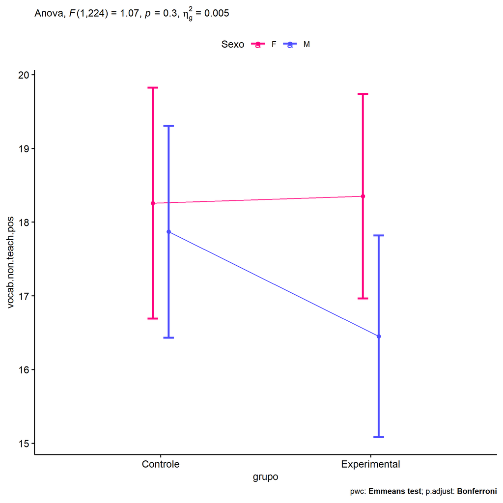

```r
if (!is.null(plots[["grupo"]]))
  plots[["grupo"]] + ggplot2::scale_color_manual(values = color[["Sexo"]])
```

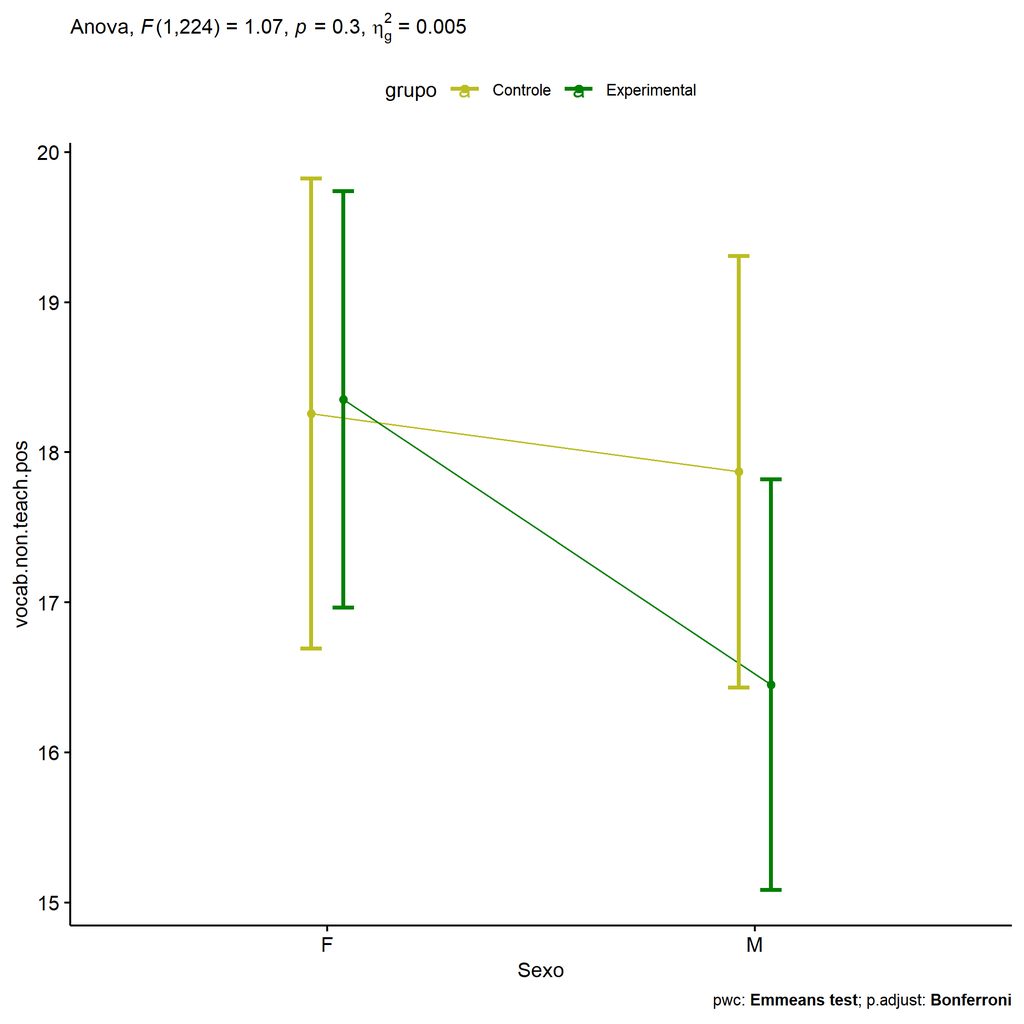

```r
if (!is.null(plots[["Sexo"]]))
  plots[["Sexo"]] + ggplot2::scale_color_manual(values = color[["grupo"]])
```

```r
plots <- twoWayAncovaBoxPlots(
  wdat, "vocab.non.teach.pos", c("grupo","Sexo"), aov, pwcs, covar = "vocab.non.teach.pre",
  theme = "classic", color = color[["grupo:Sexo"]],
  subtitle = which(aov$Effect == "grupo:Sexo"))
```

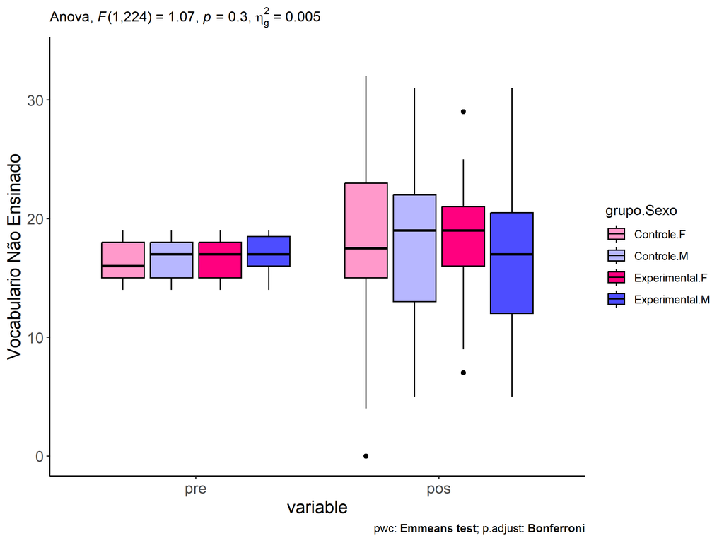

```r
plots[["grupo:Sexo"]] + ggplot2::ylab("Vocabulario Não Ensinado") + ggplot2::scale_x_discrete(labels=c('pre', 'pos'))
```

```r
plots <- twoWayAncovaBoxPlots(
  wdat.long, "vocab.non.teach", c("grupo","Sexo"), aov, pwc.long, pre.post = "time",
  theme = "classic", color = color$prepost)
```

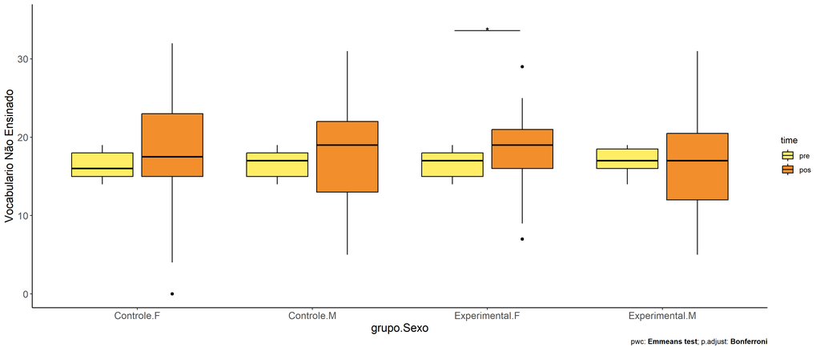

```r
plots[["grupo:Sexo"]] + ggplot2::ylab("Vocabulario Não Ensinado")
```

### Checking linearity assumption

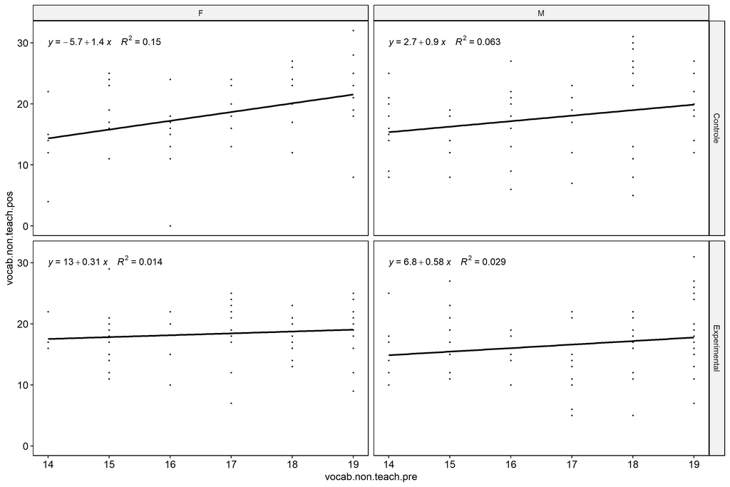

```r
ggscatter(wdat, x = "vocab.non.teach.pre", y = "vocab.non.teach.pos", size = 0.5,
          facet.by = c("grupo","Sexo"), add = "reg.line")+
  stat_regline_equation(
    aes(label =  paste(..eq.label.., ..rr.label.., sep = "~~~~"))
  )
```

### Checking normality and homogeneity

```r
res <- augment(lm(vocab.non.teach.pos ~ vocab.non.teach.pre + grupo*Sexo, data = wdat))
```

```r
shapiro_test(res$.resid)
```

```
## # A tibble: 1 × 3
##   variable   statistic p.value
##   <chr>          <dbl>   <dbl>
## 1 res$.resid     0.991   0.153
```

```r
levene_test(res, .resid ~ grupo*Sexo)
```

```
## # A tibble: 1 × 4
##     df1   df2 statistic      p
##   <int> <int>     <dbl>  <dbl>
## 1     3   225      2.12 0.0987
```

# ANCOVA and Pairwise for two factors **grupo:Zona**

## Without remove non-normal data

```r
pdat = remove_group_data(dat[!is.na(dat[["grupo"]]) & !is.na(dat[["Zona"]]),], "vocab.non.teach.pos", c("grupo","Zona"))

pdat.long <- rbind(pdat[,c("id","grupo","Zona")], pdat[,c("id","grupo","Zona")])
pdat.long[["time"]] <- c(rep("pre", nrow(pdat)), rep("pos", nrow(pdat)))
pdat.long[["time"]] <- factor(pdat.long[["time"]], c("pre","pos"))
pdat.long[["vocab.non.teach"]] <- c(pdat[["vocab.non.teach.pre"]], pdat[["vocab.non.teach.pos"]])

aov = anova_test(pdat, vocab.non.teach.pos ~ vocab.non.teach.pre + grupo*Zona)
laov[["grupo:Zona"]] <- get_anova_table(aov)
```

```r
pwcs <- list()
pwcs[["Zona"]] <- emmeans_test(
  group_by(pdat, grupo), vocab.non.teach.pos ~ Zona,
  covariate = vocab.non.teach.pre, p.adjust.method = "bonferroni")
pwcs[["grupo"]] <- emmeans_test(
  group_by(pdat, Zona), vocab.non.teach.pos ~ grupo,
  covariate = vocab.non.teach.pre, p.adjust.method = "bonferroni")

pwc <- plyr::rbind.fill(pwcs[["grupo"]], pwcs[["Zona"]])
pwc <- pwc[,c("grupo","Zona", colnames(pwc)[!colnames(pwc) %in% c("grupo","Zona")])]
```

```r
pwc.long <- emmeans_test(dplyr::group_by_at(pdat.long, c("grupo","Zona")),
                         vocab.non.teach ~ time,
                         p.adjust.method = "bonferroni")
lpwc[["grupo:Zona"]] <- plyr::rbind.fill(pwc, pwc.long)
```

```r
ds <- get.descriptives(pdat, "vocab.non.teach.pos", c("grupo","Zona"), covar = "vocab.non.teach.pre")
ds <- merge(ds[ds$variable != "vocab.non.teach.pre",],
            ds[ds$variable == "vocab.non.teach.pre", !colnames(ds) %in% c("variable")],
            by = c("grupo","Zona"), all.x = T, suffixes = c("", ".vocab.non.teach.pre"))
ds <- merge(get_emmeans(pwcs[["grupo"]]), ds, by = c("grupo","Zona"), suffixes = c(".emms", ""))
ds <- ds[,c("grupo","Zona","n","mean.vocab.non.teach.pre","se.vocab.non.teach.pre","mean","se","emmean","se.emms")]

colnames(ds) <- c("grupo","Zona", "N", paste0(c("M","SE")," (pre)"),
                  paste0(c("M","SE"), " (unadj)"), paste0(c("M", "SE"), " (adj)"))

lemms[["grupo:Zona"]] <- ds
```

## Computing ANCOVA and PairWise After removing non-normal data (OK)

```r
wdat = pdat

res = residuals(lm(vocab.non.teach.pos ~ vocab.non.teach.pre + grupo*Zona, data = wdat))
non.normal = getNonNormal(res, wdat$id, plimit = 0.05)

wdat = wdat[!wdat$id %in% non.normal,]

wdat.long <- rbind(wdat[,c("id","grupo","Zona")], wdat[,c("id","grupo","Zona")])
wdat.long[["time"]] <- c(rep("pre", nrow(wdat)), rep("pos", nrow(wdat)))
wdat.long[["time"]] <- factor(wdat.long[["time"]], c("pre","pos"))
wdat.long[["vocab.non.teach"]] <- c(wdat[["vocab.non.teach.pre"]], wdat[["vocab.non.teach.pos"]])


ldat[["grupo:Zona"]] = wdat

(non.normal)
```

```r
aov = anova_test(wdat, vocab.non.teach.pos ~ vocab.non.teach.pre + grupo*Zona)
laov[["grupo:Zona"]] <- merge(get_anova_table(aov), laov[["grupo:Zona"]], by="Effect", suffixes = c("","'"))

(df = get_anova_table(aov))
```

```
## ANOVA Table (type II tests)
##
##                Effect DFn DFd      F        p p<.05      ges
## 1 vocab.non.teach.pre   1 159 14.403 0.000209     * 8.30e-02
## 2               grupo   1 159  0.711 0.400000       4.00e-03
## 3                Zona   1 159  0.578 0.448000       4.00e-03
## 4          grupo:Zona   1 159  0.011 0.915000       7.19e-05
```

| Effect | DFn | DFd | F | p | p<.05 | ges |
| --- | --- | --- | --- | --- | --- | --- |
| vocab.non.teach.pre | 1 | 159 | 14.403 | 0.000 | * | 0.083 |
| grupo | 1 | 159 | 0.711 | 0.400 |  | 0.004 |
| Zona | 1 | 159 | 0.578 | 0.448 |  | 0.004 |
| grupo:Zona | 1 | 159 | 0.011 | 0.915 |  | 0.000 |

```r
pwcs <- list()
pwcs[["Zona"]] <- emmeans_test(
  group_by(wdat, grupo), vocab.non.teach.pos ~ Zona,
  covariate = vocab.non.teach.pre, p.adjust.method = "bonferroni")
pwcs[["grupo"]] <- emmeans_test(
  group_by(wdat, Zona), vocab.non.teach.pos ~ grupo,
  covariate = vocab.non.teach.pre, p.adjust.method = "bonferroni")

pwc <- plyr::rbind.fill(pwcs[["grupo"]], pwcs[["Zona"]])
pwc <- pwc[,c("grupo","Zona", colnames(pwc)[!colnames(pwc) %in% c("grupo","Zona")])]
```

| grupo | Zona | term | .y. | group1 | group2 | df | statistic | p | p.adj | p.adj.signif |
| --- | --- | --- | --- | --- | --- | --- | --- | --- | --- | --- |
|  | Rural | vocab.non.teach.pre*grupo | vocab.non.teach.pos | Controle | Experimental | 159 | 0.624 | 0.534 | 0.534 | ns |
|  | Urbana | vocab.non.teach.pre*grupo | vocab.non.teach.pos | Controle | Experimental | 159 | 0.580 | 0.562 | 0.562 | ns |
| Controle |  | vocab.non.teach.pre*Zona | vocab.non.teach.pos | Rural | Urbana | 159 | -0.588 | 0.558 | 0.558 | ns |
| Experimental |  | vocab.non.teach.pre*Zona | vocab.non.teach.pos | Rural | Urbana | 159 | -0.495 | 0.621 | 0.621 | ns |

```r
pwc.long <- emmeans_test(dplyr::group_by_at(wdat.long, c("grupo","Zona")),
                         vocab.non.teach ~ time,
                         p.adjust.method = "bonferroni")
lpwc[["grupo:Zona"]] <- merge(plyr::rbind.fill(pwc, pwc.long), lpwc[["grupo:Zona"]], by=c("grupo","Zona","term",".y.","group1","group2"), suffixes = c("","'"))
```

| grupo | Zona | term | .y. | group1 | group2 | df | statistic | p | p.adj | p.adj.signif |
| --- | --- | --- | --- | --- | --- | --- | --- | --- | --- | --- |
| Controle | Rural | time | vocab.non.teach | pre | pos | 320 | -1.686 | 0.093 | 0.093 | ns |
| Controle | Urbana | time | vocab.non.teach | pre | pos | 320 | -1.799 | 0.073 | 0.073 | ns |
| Experimental | Rural | time | vocab.non.teach | pre | pos | 320 | -0.870 | 0.385 | 0.385 | ns |
| Experimental | Urbana | time | vocab.non.teach | pre | pos | 320 | -1.264 | 0.207 | 0.207 | ns |

```r
ds <- get.descriptives(wdat, "vocab.non.teach.pos", c("grupo","Zona"), covar = "vocab.non.teach.pre")
ds <- merge(ds[ds$variable != "vocab.non.teach.pre",],
            ds[ds$variable == "vocab.non.teach.pre", !colnames(ds) %in% c("variable")],
            by = c("grupo","Zona"), all.x = T, suffixes = c("", ".vocab.non.teach.pre"))
ds <- merge(get_emmeans(pwcs[["grupo"]]), ds, by = c("grupo","Zona"), suffixes = c(".emms", ""))
ds <- ds[,c("grupo","Zona","n","mean.vocab.non.teach.pre","se.vocab.non.teach.pre","mean","se","emmean","se.emms")]

colnames(ds) <- c("grupo","Zona", "N", paste0(c("M","SE")," (pre)"),
                  paste0(c("M","SE"), " (unadj)"), paste0(c("M", "SE"), " (adj)"))

lemms[["grupo:Zona"]] <- merge(ds, lemms[["grupo:Zona"]], by=c("grupo","Zona"), suffixes = c("","'"))
```

| grupo | Zona | N | M (pre) | SE (pre) | M (unadj) | SE (unadj) | M (adj) | SE (adj) |
| --- | --- | --- | --- | --- | --- | --- | --- | --- |
| Controle | Rural | 53 | 16.774 | 0.252 | 18.113 | 0.904 | 18.172 | 0.731 |
| Controle | Urbana | 24 | 16.458 | 0.307 | 18.583 | 1.014 | 18.943 | 1.090 |
| Experimental | Rural | 54 | 17.019 | 0.216 | 17.704 | 0.699 | 17.529 | 0.725 |
| Experimental | Urbana | 33 | 16.909 | 0.290 | 18.182 | 0.807 | 18.112 | 0.926 |

### Plots for ancova

```r
plots <- twoWayAncovaPlots(
  wdat, "vocab.non.teach.pos", c("grupo","Zona"), aov, pwcs, addParam = c("mean_se"),
  font.label.size=10, step.increase=0.05, p.label="p.adj",
  subtitle = which(aov$Effect == "grupo:Zona"))
```

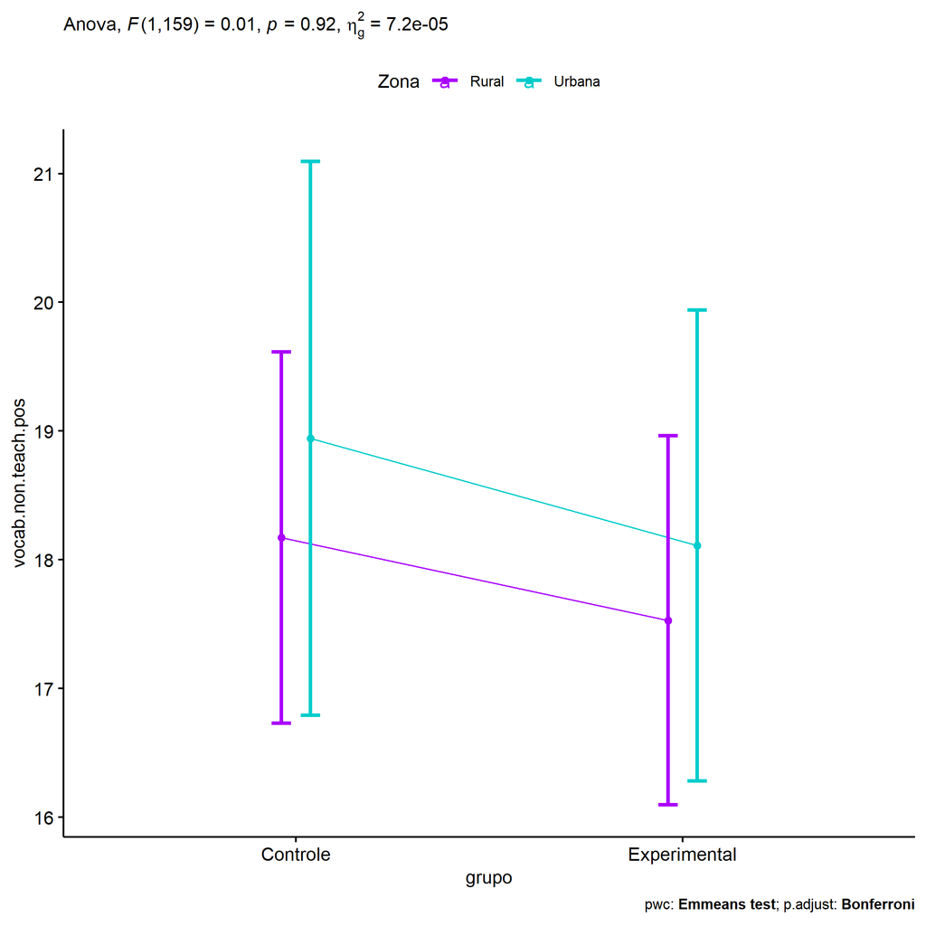

```r
if (!is.null(plots[["grupo"]]))
  plots[["grupo"]] + ggplot2::scale_color_manual(values = color[["Zona"]])
```

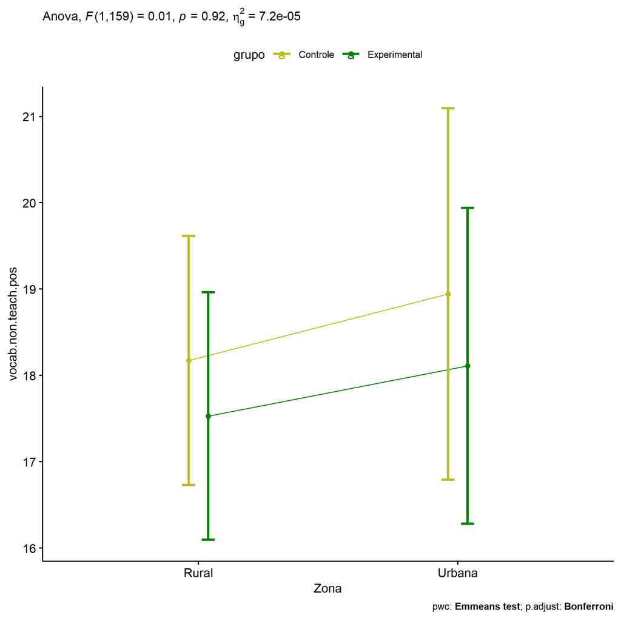

```r
if (!is.null(plots[["Zona"]]))
  plots[["Zona"]] + ggplot2::scale_color_manual(values = color[["grupo"]])
```

```r
plots <- twoWayAncovaBoxPlots(
  wdat, "vocab.non.teach.pos", c("grupo","Zona"), aov, pwcs, covar = "vocab.non.teach.pre",
  theme = "classic", color = color[["grupo:Zona"]],
  subtitle = which(aov$Effect == "grupo:Zona"))
```

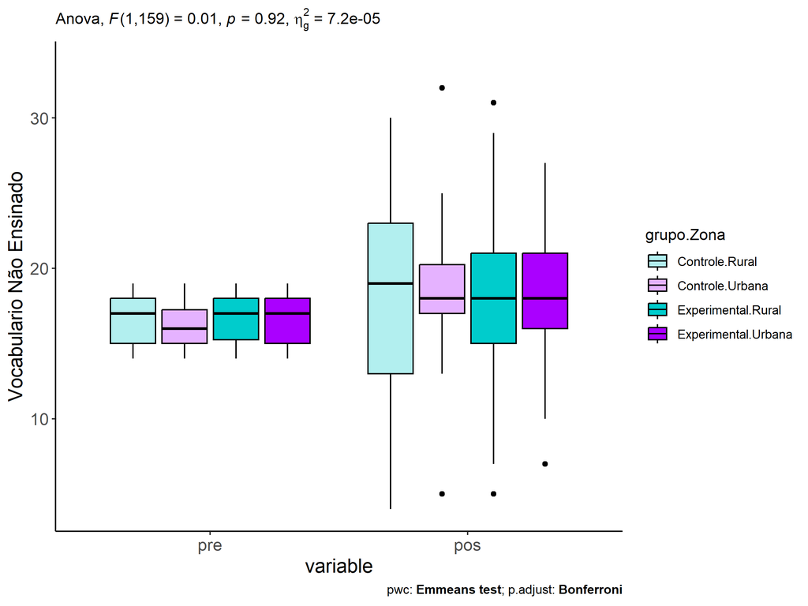

```r
plots[["grupo:Zona"]] + ggplot2::ylab("Vocabulario Não Ensinado") + ggplot2::scale_x_discrete(labels=c('pre', 'pos'))
```

```r
plots <- twoWayAncovaBoxPlots(
  wdat.long, "vocab.non.teach", c("grupo","Zona"), aov, pwc.long, pre.post = "time",
  theme = "classic", color = color$prepost)
```

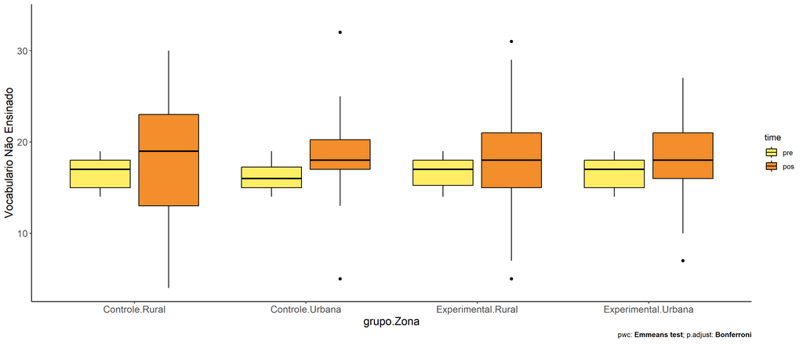

```r
plots[["grupo:Zona"]] + ggplot2::ylab("Vocabulario Não Ensinado")
```

### Checking linearity assumption

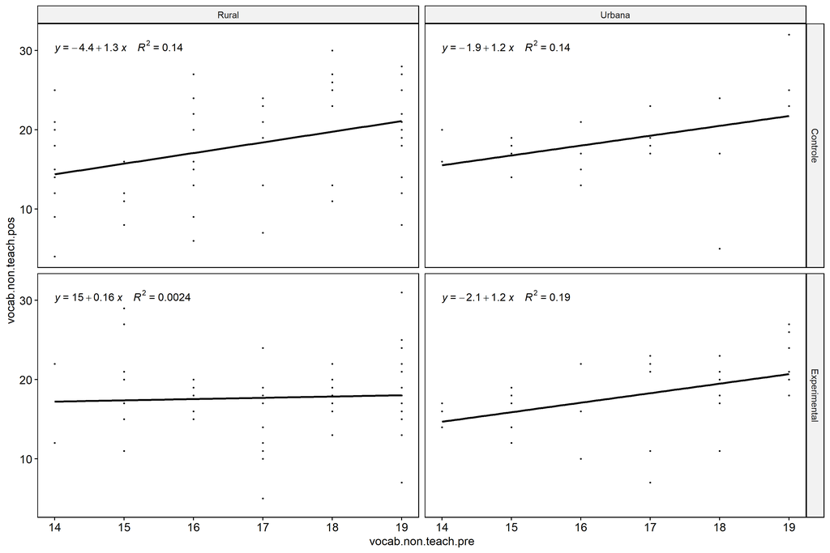

```r
ggscatter(wdat, x = "vocab.non.teach.pre", y = "vocab.non.teach.pos", size = 0.5,
          facet.by = c("grupo","Zona"), add = "reg.line")+
  stat_regline_equation(
    aes(label =  paste(..eq.label.., ..rr.label.., sep = "~~~~"))
  )
```

### Checking normality and homogeneity

```r
res <- augment(lm(vocab.non.teach.pos ~ vocab.non.teach.pre + grupo*Zona, data = wdat))
```

```r
shapiro_test(res$.resid)
```

```
## # A tibble: 1 × 3
##   variable   statistic p.value
##   <chr>          <dbl>   <dbl>
## 1 res$.resid     0.988   0.179
```

```r
levene_test(res, .resid ~ grupo*Zona)
```

```
## # A tibble: 1 × 4
##     df1   df2 statistic      p
##   <int> <int>     <dbl>  <dbl>
## 1     3   160      3.53 0.0162
```

# ANCOVA and Pairwise for two factors **grupo:Cor.Raca**

## Without remove non-normal data

```r
pdat = remove_group_data(dat[!is.na(dat[["grupo"]]) & !is.na(dat[["Cor.Raca"]]),], "vocab.non.teach.pos", c("grupo","Cor.Raca"))
pdat.long <- rbind(pdat[,c("id","grupo","Cor.Raca")], pdat[,c("id","grupo","Cor.Raca")])
pdat.long[["time"]] <- c(rep("pre", nrow(pdat)), rep("pos", nrow(pdat)))
pdat.long[["time"]] <- factor(pdat.long[["time"]], c("pre","pos"))
pdat.long[["vocab.non.teach"]] <- c(pdat[["vocab.non.teach.pre"]], pdat[["vocab.non.teach.pos"]])

aov = anova_test(pdat, vocab.non.teach.pos ~ vocab.non.teach.pre + grupo*Cor.Raca)
laov[["grupo:Cor.Raca"]] <- get_anova_table(aov)
```

```r
pwcs <- list()
pwcs[["Cor.Raca"]] <- emmeans_test(
  group_by(pdat, grupo), vocab.non.teach.pos ~ Cor.Raca,
  covariate = vocab.non.teach.pre, p.adjust.method = "bonferroni")
pwcs[["grupo"]] <- emmeans_test(
  group_by(pdat, Cor.Raca), vocab.non.teach.pos ~ grupo,
  covariate = vocab.non.teach.pre, p.adjust.method = "bonferroni")

pwc <- plyr::rbind.fill(pwcs[["grupo"]], pwcs[["Cor.Raca"]])
pwc <- pwc[,c("grupo","Cor.Raca", colnames(pwc)[!colnames(pwc) %in% c("grupo","Cor.Raca")])]
```

```r
pwc.long <- emmeans_test(dplyr::group_by_at(pdat.long, c("grupo","Cor.Raca")),
                         vocab.non.teach ~ time,
                         p.adjust.method = "bonferroni")
lpwc[["grupo:Cor.Raca"]] <- plyr::rbind.fill(pwc, pwc.long)
```

```r
ds <- get.descriptives(pdat, "vocab.non.teach.pos", c("grupo","Cor.Raca"), covar = "vocab.non.teach.pre")
ds <- merge(ds[ds$variable != "vocab.non.teach.pre",],
            ds[ds$variable == "vocab.non.teach.pre", !colnames(ds) %in% c("variable")],
            by = c("grupo","Cor.Raca"), all.x = T, suffixes = c("", ".vocab.non.teach.pre"))
ds <- merge(get_emmeans(pwcs[["grupo"]]), ds, by = c("grupo","Cor.Raca"), suffixes = c(".emms", ""))
ds <- ds[,c("grupo","Cor.Raca","n","mean.vocab.non.teach.pre","se.vocab.non.teach.pre","mean","se","emmean","se.emms")]

colnames(ds) <- c("grupo","Cor.Raca", "N", paste0(c("M","SE")," (pre)"),
                  paste0(c("M","SE"), " (unadj)"), paste0(c("M", "SE"), " (adj)"))

lemms[["grupo:Cor.Raca"]] <- ds
```

## Computing ANCOVA and PairWise After removing non-normal data (OK)

```r
wdat = pdat

res = residuals(lm(vocab.non.teach.pos ~ vocab.non.teach.pre + grupo*Cor.Raca, data = wdat))
non.normal = getNonNormal(res, wdat$id, plimit = 0.05)

wdat = wdat[!wdat$id %in% non.normal,]

wdat.long <- rbind(wdat[,c("id","grupo","Cor.Raca")], wdat[,c("id","grupo","Cor.Raca")])
wdat.long[["time"]] <- c(rep("pre", nrow(wdat)), rep("pos", nrow(wdat)))
wdat.long[["time"]] <- factor(wdat.long[["time"]], c("pre","pos"))
wdat.long[["vocab.non.teach"]] <- c(wdat[["vocab.non.teach.pre"]], wdat[["vocab.non.teach.pos"]])


ldat[["grupo:Cor.Raca"]] = wdat

(non.normal)
```

```r
aov = anova_test(wdat, vocab.non.teach.pos ~ vocab.non.teach.pre + grupo*Cor.Raca)
laov[["grupo:Cor.Raca"]] <- merge(get_anova_table(aov), laov[["grupo:Cor.Raca"]], by="Effect", suffixes = c("","'"))

(df = get_anova_table(aov))
```

```
## ANOVA Table (type II tests)
##
##                Effect DFn DFd     F     p p<.05   ges
## 1 vocab.non.teach.pre   1  95 8.433 0.005     * 0.082
## 2               grupo   1  95 1.798 0.183       0.019
## 3            Cor.Raca   1  95 4.873 0.030     * 0.049
## 4      grupo:Cor.Raca   1  95 1.884 0.173       0.019
```

| Effect | DFn | DFd | F | p | p<.05 | ges |
| --- | --- | --- | --- | --- | --- | --- |
| vocab.non.teach.pre | 1 | 95 | 8.433 | 0.005 | * | 0.082 |
| grupo | 1 | 95 | 1.798 | 0.183 |  | 0.019 |
| Cor.Raca | 1 | 95 | 4.873 | 0.030 | * | 0.049 |
| grupo:Cor.Raca | 1 | 95 | 1.884 | 0.173 |  | 0.019 |

```r
pwcs <- list()
pwcs[["Cor.Raca"]] <- emmeans_test(
  group_by(wdat, grupo), vocab.non.teach.pos ~ Cor.Raca,
  covariate = vocab.non.teach.pre, p.adjust.method = "bonferroni")
pwcs[["grupo"]] <- emmeans_test(
  group_by(wdat, Cor.Raca), vocab.non.teach.pos ~ grupo,
  covariate = vocab.non.teach.pre, p.adjust.method = "bonferroni")

pwc <- plyr::rbind.fill(pwcs[["grupo"]], pwcs[["Cor.Raca"]])
pwc <- pwc[,c("grupo","Cor.Raca", colnames(pwc)[!colnames(pwc) %in% c("grupo","Cor.Raca")])]
```

| grupo | Cor.Raca | term | .y. | group1 | group2 | df | statistic | p | p.adj | p.adj.signif |
| --- | --- | --- | --- | --- | --- | --- | --- | --- | --- | --- |
|  | Branca | vocab.non.teach.pre*grupo | vocab.non.teach.pos | Controle | Experimental | 95 | 1.849 | 0.067 | 0.067 | ns |
|  | Parda | vocab.non.teach.pre*grupo | vocab.non.teach.pos | Controle | Experimental | 95 | 0.520 | 0.604 | 0.604 | ns |
| Controle |  | vocab.non.teach.pre*Cor.Raca | vocab.non.teach.pos | Branca | Parda | 95 | -0.533 | 0.595 | 0.595 | ns |
| Experimental |  | vocab.non.teach.pre*Cor.Raca | vocab.non.teach.pos | Branca | Parda | 95 | -2.547 | 0.012 | 0.012 | * |

```r
pwc.long <- emmeans_test(dplyr::group_by_at(wdat.long, c("grupo","Cor.Raca")),
                         vocab.non.teach ~ time,
                         p.adjust.method = "bonferroni")
lpwc[["grupo:Cor.Raca"]] <- merge(plyr::rbind.fill(pwc, pwc.long), lpwc[["grupo:Cor.Raca"]], by=c("grupo","Cor.Raca","term",".y.","group1","group2"), suffixes = c("","'"))
```

| grupo | Cor.Raca | term | .y. | group1 | group2 | df | statistic | p | p.adj | p.adj.signif |
| --- | --- | --- | --- | --- | --- | --- | --- | --- | --- | --- |
| Controle | Branca | time | vocab.non.teach | pre | pos | 192 | -0.621 | 0.535 | 0.535 | ns |
| Controle | Parda | time | vocab.non.teach | pre | pos | 192 | -2.166 | 0.032 | 0.032 | * |
| Experimental | Branca | time | vocab.non.teach | pre | pos | 192 | 1.830 | 0.069 | 0.069 | ns |
| Experimental | Parda | time | vocab.non.teach | pre | pos | 192 | -1.584 | 0.115 | 0.115 | ns |

```r
ds <- get.descriptives(wdat, "vocab.non.teach.pos", c("grupo","Cor.Raca"), covar = "vocab.non.teach.pre")
ds <- merge(ds[ds$variable != "vocab.non.teach.pre",],
            ds[ds$variable == "vocab.non.teach.pre", !colnames(ds) %in% c("variable")],
            by = c("grupo","Cor.Raca"), all.x = T, suffixes = c("", ".vocab.non.teach.pre"))
ds <- merge(get_emmeans(pwcs[["grupo"]]), ds, by = c("grupo","Cor.Raca"), suffixes = c(".emms", ""))
ds <- ds[,c("grupo","Cor.Raca","n","mean.vocab.non.teach.pre","se.vocab.non.teach.pre","mean","se","emmean","se.emms")]

colnames(ds) <- c("grupo","Cor.Raca", "N", paste0(c("M","SE")," (pre)"),
                  paste0(c("M","SE"), " (unadj)"), paste0(c("M", "SE"), " (adj)"))

lemms[["grupo:Cor.Raca"]] <- merge(ds, lemms[["grupo:Cor.Raca"]], by=c("grupo","Cor.Raca"), suffixes = c("","'"))
```

| grupo | Cor.Raca | N | M (pre) | SE (pre) | M (unadj) | SE (unadj) | M (adj) | SE (adj) |
| --- | --- | --- | --- | --- | --- | --- | --- | --- |
| Controle | Branca | 11 | 17.091 | 0.563 | 18.273 | 1.864 | 18.119 | 1.757 |
| Controle | Parda | 36 | 16.583 | 0.307 | 18.861 | 1.250 | 19.193 | 0.977 |
| Experimental | Branca | 12 | 17.417 | 0.543 | 14.083 | 1.264 | 13.618 | 1.689 |
| Experimental | Parda | 41 | 17.049 | 0.270 | 18.610 | 0.760 | 18.496 | 0.911 |

### Plots for ancova

```r
plots <- twoWayAncovaPlots(
  wdat, "vocab.non.teach.pos", c("grupo","Cor.Raca"), aov, pwcs, addParam = c("mean_se"),
  font.label.size=10, step.increase=0.05, p.label="p.adj",
  subtitle = which(aov$Effect == "grupo:Cor.Raca"))
```

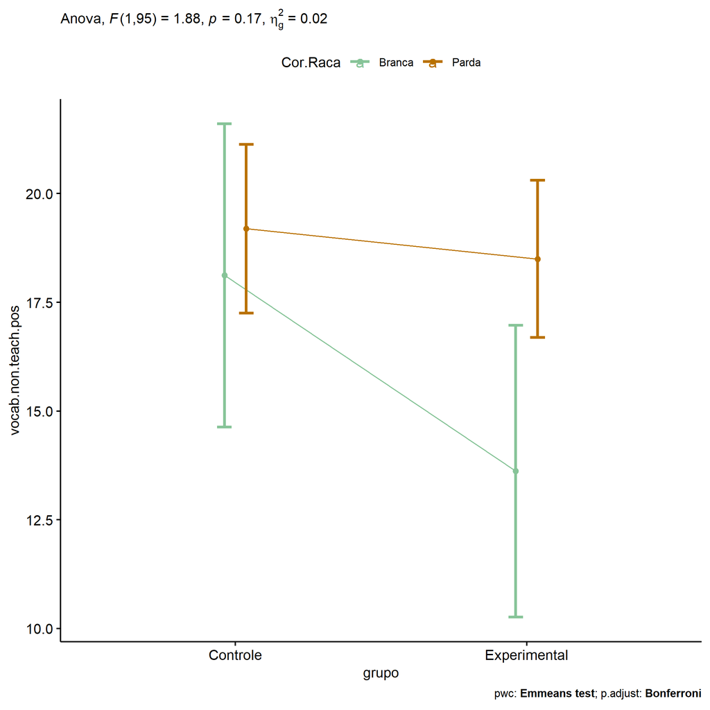

```r
if (!is.null(plots[["grupo"]]))
  plots[["grupo"]] + ggplot2::scale_color_manual(values = color[["Cor.Raca"]])
```

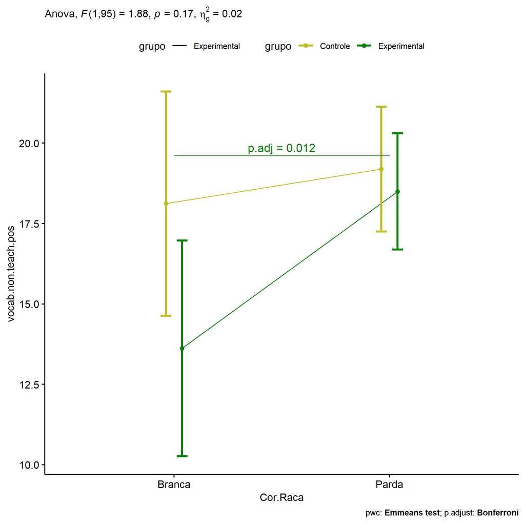

```r
if (!is.null(plots[["Cor.Raca"]]))
  plots[["Cor.Raca"]] + ggplot2::scale_color_manual(values = color[["grupo"]])
```

```r
plots <- twoWayAncovaBoxPlots(
  wdat, "vocab.non.teach.pos", c("grupo","Cor.Raca"), aov, pwcs, covar = "vocab.non.teach.pre",
  theme = "classic", color = color[["grupo:Cor.Raca"]],
  subtitle = which(aov$Effect == "grupo:Cor.Raca"))
```

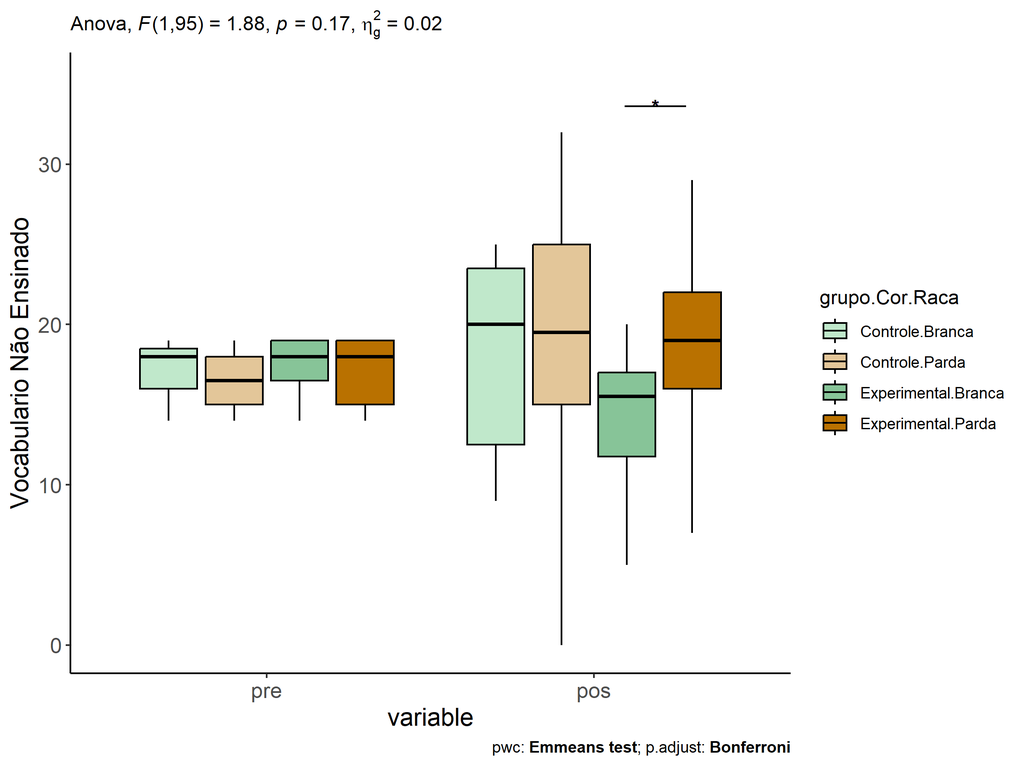

```r
plots[["grupo:Cor.Raca"]] + ggplot2::ylab("Vocabulario Não Ensinado") + ggplot2::scale_x_discrete(labels=c('pre', 'pos'))
```

```r
plots <- twoWayAncovaBoxPlots(
  wdat.long, "vocab.non.teach", c("grupo","Cor.Raca"), aov, pwc.long, pre.post = "time",
  theme = "classic", color = color$prepost)
```

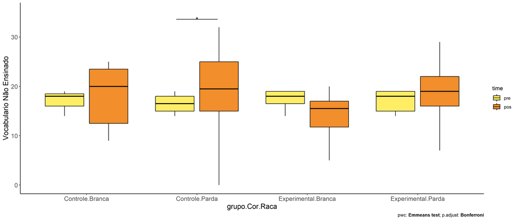

```r
plots[["grupo:Cor.Raca"]] + ggplot2::ylab("Vocabulario Não Ensinado")
```

### Checking linearity assumption

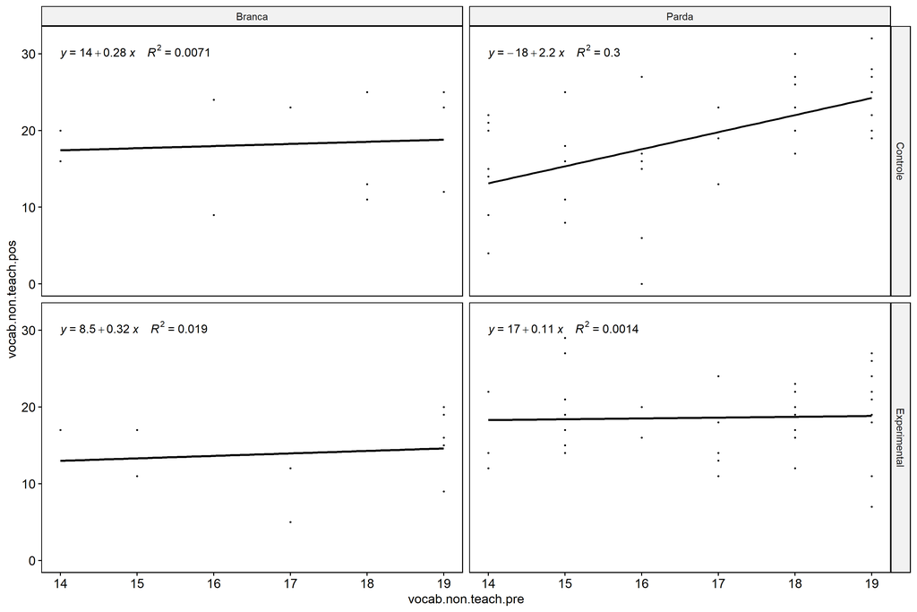

```r
ggscatter(wdat, x = "vocab.non.teach.pre", y = "vocab.non.teach.pos", size = 0.5,
          facet.by = c("grupo","Cor.Raca"), add = "reg.line")+
  stat_regline_equation(
    aes(label =  paste(..eq.label.., ..rr.label.., sep = "~~~~"))
  )
```

### Checking normality and homogeneity

```r
res <- augment(lm(vocab.non.teach.pos ~ vocab.non.teach.pre + grupo*Cor.Raca, data = wdat))
```

```r
shapiro_test(res$.resid)
```

```
## # A tibble: 1 × 3
##   variable   statistic p.value
##   <chr>          <dbl>   <dbl>
## 1 res$.resid     0.980   0.145
```

```r
levene_test(res, .resid ~ grupo*Cor.Raca)
```

```
## # A tibble: 1 × 4
##     df1   df2 statistic     p
##   <int> <int>     <dbl> <dbl>
## 1     3    96      1.37 0.256
```

# ANCOVA and Pairwise for two factors **grupo:Serie**

## Without remove non-normal data

```r
pdat = remove_group_data(dat[!is.na(dat[["grupo"]]) & !is.na(dat[["Serie"]]),], "vocab.non.teach.pos", c("grupo","Serie"))

pdat.long <- rbind(pdat[,c("id","grupo","Serie")], pdat[,c("id","grupo","Serie")])
pdat.long[["time"]] <- c(rep("pre", nrow(pdat)), rep("pos", nrow(pdat)))
pdat.long[["time"]] <- factor(pdat.long[["time"]], c("pre","pos"))
pdat.long[["vocab.non.teach"]] <- c(pdat[["vocab.non.teach.pre"]], pdat[["vocab.non.teach.pos"]])

aov = anova_test(pdat, vocab.non.teach.pos ~ vocab.non.teach.pre + grupo*Serie)
laov[["grupo:Serie"]] <- get_anova_table(aov)
```

```r
pwcs <- list()
pwcs[["Serie"]] <- emmeans_test(
  group_by(pdat, grupo), vocab.non.teach.pos ~ Serie,
  covariate = vocab.non.teach.pre, p.adjust.method = "bonferroni")
pwcs[["grupo"]] <- emmeans_test(
  group_by(pdat, Serie), vocab.non.teach.pos ~ grupo,
  covariate = vocab.non.teach.pre, p.adjust.method = "bonferroni")

pwc <- plyr::rbind.fill(pwcs[["grupo"]], pwcs[["Serie"]])
pwc <- pwc[,c("grupo","Serie", colnames(pwc)[!colnames(pwc) %in% c("grupo","Serie")])]
```

```r
pwc.long <- emmeans_test(dplyr::group_by_at(pdat.long, c("grupo","Serie")),
                         vocab.non.teach ~ time,
                         p.adjust.method = "bonferroni")
lpwc[["grupo:Serie"]] <- plyr::rbind.fill(pwc, pwc.long)
```

```r
ds <- get.descriptives(pdat, "vocab.non.teach.pos", c("grupo","Serie"), covar = "vocab.non.teach.pre")
ds <- merge(ds[ds$variable != "vocab.non.teach.pre",],
            ds[ds$variable == "vocab.non.teach.pre", !colnames(ds) %in% c("variable")],
            by = c("grupo","Serie"), all.x = T, suffixes = c("", ".vocab.non.teach.pre"))
ds <- merge(get_emmeans(pwcs[["grupo"]]), ds, by = c("grupo","Serie"), suffixes = c(".emms", ""))
ds <- ds[,c("grupo","Serie","n","mean.vocab.non.teach.pre","se.vocab.non.teach.pre","mean","se","emmean","se.emms")]

colnames(ds) <- c("grupo","Serie", "N", paste0(c("M","SE")," (pre)"),
                  paste0(c("M","SE"), " (unadj)"), paste0(c("M", "SE"), " (adj)"))

lemms[["grupo:Serie"]] <- ds
```